# Text Mining Examples

This R Notebook was constructed using the material in “How to Use Text Mining with R” by Barkha Patel AND Sapan Mankad.

```r
library(tm)
docs = Corpus(DirSource("Text_EGs"))
docs
```

```
<<SimpleCorpus>>
Metadata:  corpus specific: 1, document level (indexed): 0
Content:  documents: 12
```

Let’s inspect a document

```r
inspect(docs[1])
```

```
<<SimpleCorpus>>
Metadata:  corpus specific: 1, document level (indexed): 0
Content:  documents: 1

                                                                                                                                                                                                                                                                                                            …
The Ugly Duckling.\n\nA duck made her nest under some leaves.\nShe sat on the eggs to keep them warm.\nAt last the eggs broke, one after the other. Little ducks came out.\nOnly one egg was left. It was a very large one.\nAt last it broke, and out came a big, ugly duckling.\n"What a big duckling!" sa…
```

### Preprocessing

Now let’s start processing the corpus

```r
docs = tm_map(docs, removePunctuation)
docs = tm_map(docs, removeNumbers)
docs = tm_map(docs, tolower)
docs = tm_map(docs, removeWords, stopwords("english"))
docs = tm_map(docs, stripWhitespace)
```

Can view **inspect** to view the entire corpus or specific elements

```r
inspect(docs[1])
```

```
<<SimpleCorpus>>
Metadata:  corpus specific: 1, document level (indexed): 0
Content:  documents: 1

                                                                                                                                                                                                                                                                                                            …
 ugly duckling duck made nest leaves sat eggs keep warm last eggs broke one little ducks came one egg left large one last broke came big ugly duckling big duckling said old duck look like us can turkeywe will see like water duck next day mother duck took ducklings pond splash splash mother duck wate…
```

```r
print(docs)
```

```
<<SimpleCorpus>>
Metadata:  corpus specific: 1, document level (indexed): 0
Content:  documents: 12
```

### Stemming

Now lets **stem** the corpus. (Stemming is the procedure of converting words to their base or root form. For example, playing, played, plays, etc, will be converted to play.)

```r
library(SnowballC)
docs = tm_map(docs, stemDocument)
inspect(docs[1])
```

```
<<SimpleCorpus>>
Metadata:  corpus specific: 1, document level (indexed): 0
Content:  documents: 1

                                                                                                                                                                                                                                                                                                            …
ugli duckl duck made nest leav sat egg keep warm last egg broke one littl duck came one egg left larg one last broke came big ugli duckl big duckl said old duck look like us can turkeyw will see like water duck next day mother duck took duckl pond splash splash mother duck water call duckl come jump…
```

### The Term-Document Matrix

NOw let’s create a term document matrix

```r
dtm = DocumentTermMatrix(docs)
dtm
```

```
<<DocumentTermMatrix (documents: 12, terms: 557)>>
Non-/sparse entries: 1314/5370
Sparsity           : 80%
Maximal term length: 10
Weighting          : term frequency (tf)
```

```r
freq = colSums(as.matrix(dtm))
ord = order(freq,decreasing=TRUE)
freq[head(ord)]
```

```
 said  loki  will  went  came littl
  139    66    61    52    51    51
```

### Finding Associations

```r
findAssocs(dtm, "loki", corlimit=0.80)
```

```
$loki
    god    cant journey    kept    mean    pass    gone    fire  faster    soon     yes
   0.91    0.91    0.91    0.91    0.91    0.91    0.90    0.89    0.88    0.86    0.84
    hit
   0.81
```

### Plotting Term Frequencies

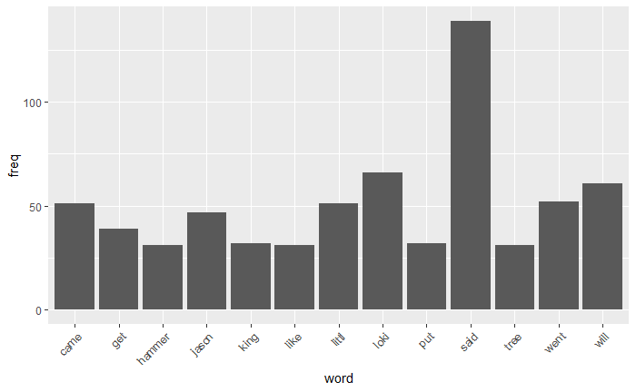

```r
library(ggplot2)
wf = data.frame(word=names(freq), freq=freq)
p = ggplot(subset(wf, freq>30), aes(word, freq))
p = p + geom_bar(stat="identity")
p = p + theme(axis.text.x=element_text(angle=45, hjust=1))
p
```

### Word Cloud

Word Cloud is another way of representing the frequency of terms in a document. Here, the size of a word indicates its frequency in the document corpus.

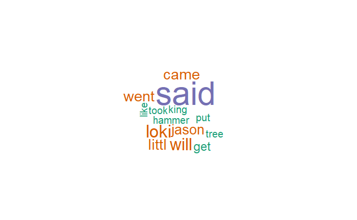

```r
library(wordcloud)
wordcloud(names(freq), freq, min.freq=30,colors=brewer.pal(3,"Dark2"))
```